# Assignment 2 DataScience

#install necessary libraries

```r
#install.packages('gridExtra')
#install.packages('ggthemes')
#install.packages('caret')
#url<- "https://cran.r-project.org/src/contrib/Archive/randomForest/randomForest_4.6-12.tar.gz"
#install.packages(url, repos=NULL, type="source")
#install.packages('party')
```

#import libraries

```r
library(plyr) #to summarize data
library(corrplot)
library(ggplot2)
library(gridExtra) #multiple plots
library(ggthemes) # package of ggplot themes
library(caret) #classification & regression
library(MASS)
library(party) #visualize decision trees
```

#read the dataset so we can use it #load the dataset

```r
Churn_Dataset <- read.csv("Churn Dataset.csv")
```

#summarize the details of the dataset

```r
summary(Churn_Dataset)
```

```
      customerID      gender     SeniorCitizen    Partner    Dependents     tenure      PhoneService          MultipleLines     InternetService
 0002-ORFBO:   1   Female:3488   Min.   :0.0000   No :3641   No :4933   Min.   : 0.00   No : 682     No              :3390   DSL        :2421
 0003-MKNFE:   1   Male  :3555   1st Qu.:0.0000   Yes:3402   Yes:2110   1st Qu.: 9.00   Yes:6361     No phone service: 682   Fiber optic:3096
 0004-TLHLJ:   1                 Median :0.0000                         Median :29.00                Yes             :2971   No         :1526
 0011-IGKFF:   1                 Mean   :0.1621                         Mean   :32.37
 0013-EXCHZ:   1                 3rd Qu.:0.0000                         3rd Qu.:55.00
 0013-MHZWF:   1                 Max.   :1.0000                         Max.   :72.00
 (Other)   :7037
             OnlineSecurity              OnlineBackup             DeviceProtection              TechSupport                StreamingTV
 No                 :3498   No                 :3088   No                 :3095    No                 :3473   No                 :2810
 No internet service:1526   No internet service:1526   No internet service:1526    No internet service:1526   No internet service:1526
 Yes                :2019   Yes                :2429   Yes                :2422    Yes                :2044   Yes                :2707




            StreamingMovies           Contract    PaperlessBilling                   PaymentMethod  MonthlyCharges    TotalCharges
 No                 :2785   Month-to-month:3875   No :2872         Bank transfer (automatic):1544   Min.   : 18.25   Min.   :  18.8
 No internet service:1526   One year      :1473   Yes:4171         Credit card (automatic)  :1522   1st Qu.: 35.50   1st Qu.: 401.4
 Yes                :2732   Two year      :1695                    Electronic check         :2365   Median : 70.35   Median :1397.5
                                                                   Mailed check             :1612   Mean   : 64.76   Mean   :2283.3
                                                                                                    3rd Qu.: 89.85   3rd Qu.:3794.7
                                                                                                    Max.   :118.75   Max.   :8684.8
                                                                                                                     NA's   :11
 Churn
 No :5174
 Yes:1869
```

#different way to summarize the dataset

```r
str(Churn_Dataset)
```

```
'data.frame':   7043 obs. of  21 variables:
 $ customerID      : Factor w/ 7043 levels "0002-ORFBO","0003-MKNFE",..: 5376 3963 2565 5536 6512 6552 1003 4771 5605 4535 ...
 $ gender          : Factor w/ 2 levels "Female","Male": 1 2 2 2 1 1 2 1 1 2 ...
 $ SeniorCitizen   : int  0 0 0 0 0 0 0 0 0 0 ...
 $ Partner         : Factor w/ 2 levels "No","Yes": 2 1 1 1 1 1 1 1 2 1 ...
 $ Dependents      : Factor w/ 2 levels "No","Yes": 1 1 1 1 1 1 2 1 1 2 ...
 $ tenure          : int  1 34 2 45 2 8 22 10 28 62 ...
 $ PhoneService    : Factor w/ 2 levels "No","Yes": 1 2 2 1 2 2 2 1 2 2 ...
 $ MultipleLines   : Factor w/ 3 levels "No","No phone service",..: 2 1 1 2 1 3 3 2 3 1 ...
 $ InternetService : Factor w/ 3 levels "DSL","Fiber optic",..: 1 1 1 1 2 2 2 1 2 1 ...
 $ OnlineSecurity  : Factor w/ 3 levels "No","No internet service",..: 1 3 3 3 1 1 1 3 1 3 ...
 $ OnlineBackup    : Factor w/ 3 levels "No","No internet service",..: 3 1 3 1 1 1 3 1 1 3 ...
 $ DeviceProtection: Factor w/ 3 levels "No","No internet service",..: 1 3 1 3 1 3 1 1 3 1 ...
 $ TechSupport     : Factor w/ 3 levels "No","No internet service",..: 1 1 1 3 1 1 1 1 3 1 ...
 $ StreamingTV     : Factor w/ 3 levels "No","No internet service",..: 1 1 1 1 1 3 3 1 3 1 ...
 $ StreamingMovies : Factor w/ 3 levels "No","No internet service",..: 1 1 1 1 1 3 1 1 3 1 ...
 $ Contract        : Factor w/ 3 levels "Month-to-month",..: 1 2 1 2 1 1 1 1 1 2 ...
 $ PaperlessBilling: Factor w/ 2 levels "No","Yes": 2 1 2 1 2 2 2 1 2 1 ...
 $ PaymentMethod   : Factor w/ 4 levels "Bank transfer (automatic)",..: 3 4 4 1 3 3 2 4 3 1 ...
 $ MonthlyCharges  : num  29.9 57 53.9 42.3 70.7 ...
 $ TotalCharges    : num  29.9 1889.5 108.2 1840.8 151.7 ...
 $ Churn           : Factor w/ 2 levels "No","Yes": 1 1 2 1 2 2 1 1 2 1 ...
```

## comment on the data :

according to the summary of the data - customerID is not useful because it give me information about the user and i find it not useful - MultipleLines contains values like “no phone service” which should be changed to “No” - OnlineSecurity, OnlineBackup, DeviceProtection, techSupport, StreamingTV and StreamingMovies  
contains values like “no internet service” which should be changed to “No”

#Data Preparation & Preprocessing #check the distribution of Churn

```r
prop.table(table(Churn_Dataset$Churn))
```

```
       No       Yes
0.7346301 0.2653699
```

#——————————————————————————- # 1. Generate a scatterplot matrix to show the relationships between the variables and a heatmap to determine correlated attributes #——————————————————————————-

# Scatter plot matrix to show the relationship between variables

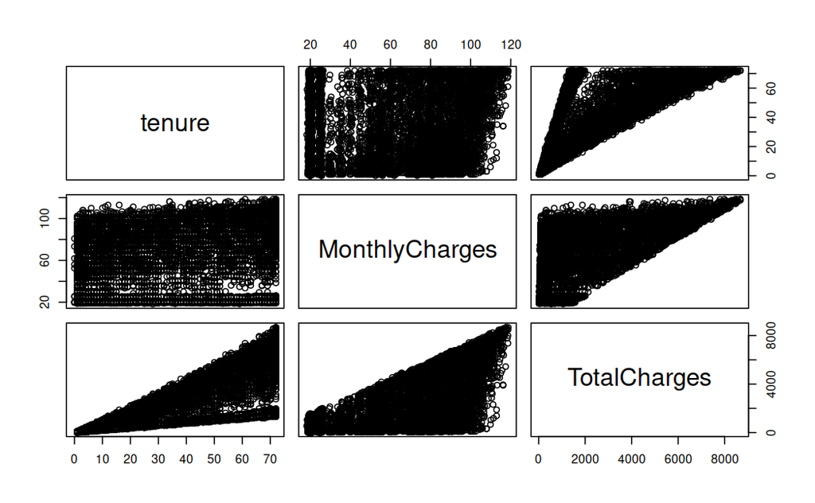

```r
library("dplyr")
numeric_data=select_if(Churn_Dataset,is.numeric)
numeric_data$SeniorCitizen=NULL
plot(numeric_data)
```

#heatmap to determine correlated attributes

```r
#install.packages("Hmisc")
```

```r
library(Hmisc)
ccs=as.matrix(numeric_data)
correlation=rcorr(ccs, type="pearson") # You can also use "spearman"
correlation_matrix=data.matrix(correlation$r)
correlation_matrix
```

```
                  tenure MonthlyCharges TotalCharges
tenure         1.0000000      0.2478999    0.8258805
MonthlyCharges 0.2478999      1.0000000    0.6510648
TotalCharges   0.8258805      0.6510648    1.0000000
```

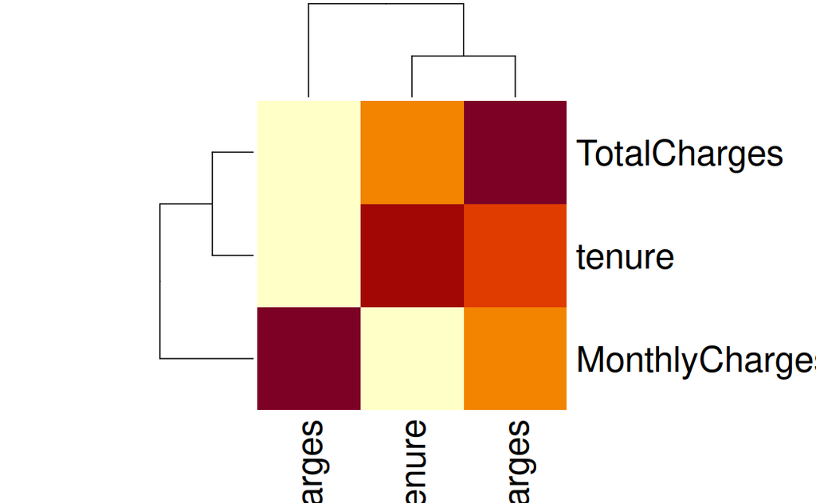

```r
heatmap(correlation_matrix)
```

#——————————————————————————- # 2. Ensure data is in the correct format for downstream processes #——————————————————————————-

#use sapply to check the number of missing values in each columns

```r
sapply(Churn_Dataset, function(x) sum(is.na(x)))
```

```
      customerID           gender    SeniorCitizen          Partner       Dependents           tenure     PhoneService    MultipleLines
               0                0                0                0                0                0                0                0
 InternetService   OnlineSecurity     OnlineBackup DeviceProtection      TechSupport      StreamingTV  StreamingMovies         Contract
               0                0                0                0                0                0                0                0
PaperlessBilling    PaymentMethod   MonthlyCharges     TotalCharges            Churn
               0                0                0               11                0
```

```r
#complete.cases: Return a logical vector indicating which cases are complete, i.e., have no missing values.
Churn_Dataset <- Churn_Dataset[complete.cases(Churn_Dataset), ]
```

```r
library(Hmisc)
Churn_Dataset$TotalCharges=impute(Churn_Dataset$TotalCharges,median)
```

#use sapply to check the number of missing values in each columns after filling the missing values with median

```r
sapply(Churn_Dataset, function(x) sum(is.na(x)))
```

```
      customerID           gender    SeniorCitizen          Partner       Dependents           tenure     PhoneService    MultipleLines
               0                0                0                0                0                0                0                0
 InternetService   OnlineSecurity     OnlineBackup DeviceProtection      TechSupport      StreamingTV  StreamingMovies         Contract
               0                0                0                0                0                0                0                0
PaperlessBilling    PaymentMethod   MonthlyCharges     TotalCharges            Churn
               0                0                0                0                0
```

```r
#complete.cases: Return a logical vector indicating which cases are complete, i.e., have no missing values.
Churn_Dataset <- Churn_Dataset[complete.cases(Churn_Dataset), ]
```

#change “No internet service” to “No” for some columns

```r
cols_recode1 <- c(10:15)
for(i in 1:ncol(Churn_Dataset[,cols_recode1]))
{
  str(Churn_Dataset[,i])
}
```

```
 Factor w/ 7043 levels "0002-ORFBO","0003-MKNFE",..: 5376 3963 2565 5536 6512 6552 1003 4771 5605 4535 ...
 Factor w/ 2 levels "Female","Male": 1 2 2 2 1 1 2 1 1 2 ...
 int [1:7032] 0 0 0 0 0 0 0 0 0 0 ...
 Factor w/ 2 levels "No","Yes": 2 1 1 1 1 1 1 1 2 1 ...
 Factor w/ 2 levels "No","Yes": 1 1 1 1 1 1 2 1 1 2 ...
 int [1:7032] 1 34 2 45 2 8 22 10 28 62 ...
```

```r
cols_recode1 <- c(10:15)
for(i in 1:ncol(Churn_Dataset[,cols_recode1]))
{
  Churn_Dataset[,cols_recode1][,i] <- as.factor(plyr::mapvalues(Churn_Dataset[,cols_recode1][,i], from=c("No internet service"),to=c("No")))
}
```

#change “No phone service” to “No” for column “MultipleLines

```r
Churn_Dataset$MultipleLines <- as.factor(plyr::mapvalues(Churn_Dataset$MultipleLines,from=c("No phone service"),to=c("No")))
```

#see the data after cleaning

```r
summary(Churn_Dataset)
```

```
      customerID      gender     SeniorCitizen    Partner    Dependents     tenure      PhoneService MultipleLines    InternetService
 0002-ORFBO:   1   Female:3483   Min.   :0.0000   No :3639   No :4933   Min.   : 1.00   No : 680     No :4065      DSL        :2416
 0003-MKNFE:   1   Male  :3549   1st Qu.:0.0000   Yes:3393   Yes:2099   1st Qu.: 9.00   Yes:6352     Yes:2967      Fiber optic:3096
 0004-TLHLJ:   1                 Median :0.0000                         Median :29.00                              No         :1520
 0011-IGKFF:   1                 Mean   :0.1624                         Mean   :32.42
 0013-EXCHZ:   1                 3rd Qu.:0.0000                         3rd Qu.:55.00
 0013-MHZWF:   1                 Max.   :1.0000                         Max.   :72.00
 (Other)   :7026
 OnlineSecurity OnlineBackup DeviceProtection TechSupport StreamingTV StreamingMovies           Contract    PaperlessBilling
 No :5017       No :4607     No :4614         No :4992    No :4329    No :4301        Month-to-month:3875   No :2864
 Yes:2015       Yes:2425     Yes:2418         Yes:2040    Yes:2703    Yes:2731        One year      :1472   Yes:4168
                                                                                      Two year      :1685




                   PaymentMethod  MonthlyCharges    TotalCharges    Churn
 Bank transfer (automatic):1542   Min.   : 18.25   Min.   :  18.8   No :5163
 Credit card (automatic)  :1521   1st Qu.: 35.59   1st Qu.: 401.4   Yes:1869
 Electronic check         :2365   Median : 70.35   Median :1397.5
 Mailed check             :1604   Mean   : 64.80   Mean   :2283.3
                                  3rd Qu.: 89.86   3rd Qu.:3794.7
                                  Max.   :118.75   Max.   :8684.8
```

#check the minimum value and the maximum value in the dataset.

```r
print("the minimum is : ");min(Churn_Dataset$tenure)
```

```
[1] "the minimum is : "
[1] 1
```

```r
print("the maximum is : ");max(Churn_Dataset$tenure)
```

```
[1] "the maximum is : "
[1] 72
```

#prepare the function to be applaied for each element in tenure feature in the dataset

```r
group_tenure <- function(tenure)
{
  if (tenure >= 0 & tenure <= 12)
    {
        return('0-12 Month')
    }
  else if(tenure > 12 & tenure <= 24)
    {
        return('12-24 Month')
    }
  else if (tenure > 24 & tenure <= 48)
    {
        return('24-48 Month')
    }
  else if (tenure > 48 & tenure <=60)
    {
        return('48-60 Month')
    }
  else if (tenure > 60)
    {
        return('> 60 Month')
    }
}
```

#applay the function to each element in the original feature and save the results as a new column in the dataset.

```r
Churn_Dataset$tenure_group <- sapply(Churn_Dataset$tenure,group_tenure)
Churn_Dataset$tenure_group <- as.factor(Churn_Dataset$tenure_group)
```

#Change the values in column “SeniorCitizen” from 0 or 1 to “No” or “Yes”.

```r
Churn_Dataset$SeniorCitizen <- as.factor(plyr::mapvalues(Churn_Dataset$SeniorCitizen,from=c("0","1"),to=c("No", "Yes")))
```

#Remove the columns we do not need for the analysis:

```r
Churn_Dataset$customerID <- NULL
Churn_Dataset$tenure <- NULL
```

i have deleted the tenure column because i have already built another column “tenure_group” based on it # Drop th duplicated values

```r
print("before deleting the dublicated values ")
```

```
[1] "before deleting the dublicated values "
```

```r
print(sum(duplicated(Churn_Dataset)))
```

```
[1] 22
```

```r
Churn_Dataset=Churn_Dataset[!duplicated(Churn_Dataset),]
print("after deleting the dublicated values ")
```

```
[1] "after deleting the dublicated values "
```

```r
print(sum(duplicated(Churn_Dataset)))
```

```
[1] 0
```

#******************************************************************************* ##Exploratory data analysis and feature selection #check all the features and return the numeric variables

```r
numeric.var <- sapply(Churn_Dataset, is.numeric) ## Find numerical variables
numeric.var
```

```
          gender    SeniorCitizen          Partner       Dependents     PhoneService    MultipleLines  InternetService   OnlineSecurity
           FALSE            FALSE            FALSE            FALSE            FALSE            FALSE            FALSE            FALSE
    OnlineBackup DeviceProtection      TechSupport      StreamingTV  StreamingMovies         Contract PaperlessBilling    PaymentMethod
           FALSE            FALSE            FALSE            FALSE            FALSE            FALSE            FALSE            FALSE
  MonthlyCharges     TotalCharges            Churn     tenure_group
            TRUE             TRUE            FALSE            FALSE
```

#plot the correlation matrix for all the numeric features just to reduce number of features that’s going to be the input of the model

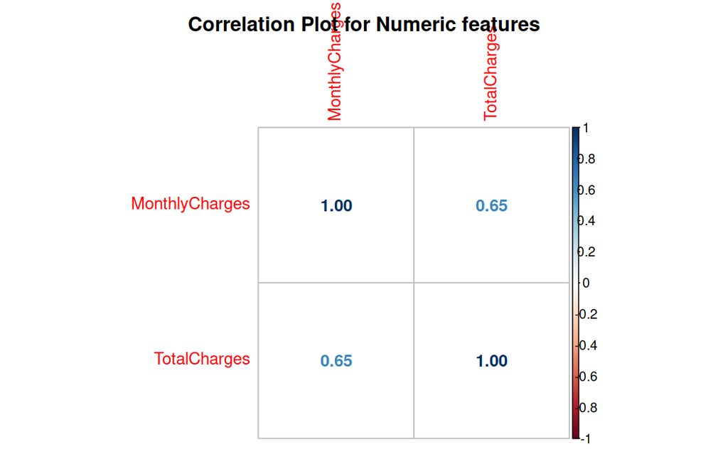

```r
corr.matrix <- cor(Churn_Dataset[,numeric.var])  ## Calculate the correlation matrix
corrplot(corr.matrix, main="\n\nCorrelation Plot for Numeric features", method="number")
```

after prepare the data i built again the correlation matrix so i can see the features that give me no new information by checking their correlations

The Monthly Charges and Total Charges features are correlated. So one of them will be removed from the model.I will remove Total Charges.

```r
Churn_Dataset$TotalCharges <- NULL
```

## Bar plots of categorical variables

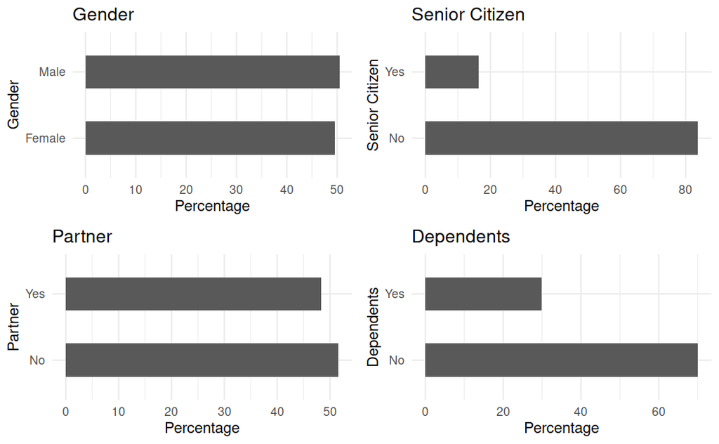

```r
p1 <- ggplot(Churn_Dataset, aes(x=gender)) + ggtitle("Gender") + xlab("Gender") +
  geom_bar(aes(y = 100*(..count..)/sum(..count..)), width = 0.5) + ylab("Percentage") + coord_flip() + theme_minimal()
p2 <- ggplot(Churn_Dataset, aes(x=SeniorCitizen)) + ggtitle("Senior Citizen") + xlab("Senior Citizen") +
  geom_bar(aes(y = 100*(..count..)/sum(..count..)), width = 0.5) + ylab("Percentage") + coord_flip() + theme_minimal()
p3 <- ggplot(Churn_Dataset, aes(x=Partner)) + ggtitle("Partner") + xlab("Partner") +
  geom_bar(aes(y = 100*(..count..)/sum(..count..)), width = 0.5) + ylab("Percentage") + coord_flip() + theme_minimal()
p4 <- ggplot(Churn_Dataset, aes(x=Dependents)) + ggtitle("Dependents") + xlab("Dependents") +
  geom_bar(aes(y = 100*(..count..)/sum(..count..)), width = 0.5) + ylab("Percentage") + coord_flip() + theme_minimal()
grid.arrange(p1, p2, p3, p4, ncol=2)
```

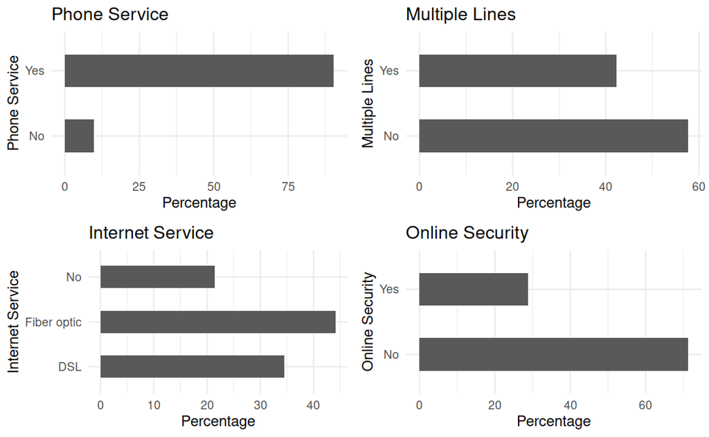

```r
p5 <- ggplot(Churn_Dataset, aes(x=PhoneService)) + ggtitle("Phone Service") + xlab("Phone Service") +
  geom_bar(aes(y = 100*(..count..)/sum(..count..)), width = 0.5) + ylab("Percentage") + coord_flip() + theme_minimal()
p6 <- ggplot(Churn_Dataset, aes(x=MultipleLines)) + ggtitle("Multiple Lines") + xlab("Multiple Lines") +
  geom_bar(aes(y = 100*(..count..)/sum(..count..)), width = 0.5) + ylab("Percentage") + coord_flip() + theme_minimal()
p7 <- ggplot(Churn_Dataset, aes(x=InternetService)) + ggtitle("Internet Service") + xlab("Internet Service") +
  geom_bar(aes(y = 100*(..count..)/sum(..count..)), width = 0.5) + ylab("Percentage") + coord_flip() + theme_minimal()
p8 <- ggplot(Churn_Dataset, aes(x=OnlineSecurity)) + ggtitle("Online Security") + xlab("Online Security") +
  geom_bar(aes(y = 100*(..count..)/sum(..count..)), width = 0.5) + ylab("Percentage") + coord_flip() + theme_minimal()
grid.arrange(p5, p6, p7, p8, ncol=2)
```

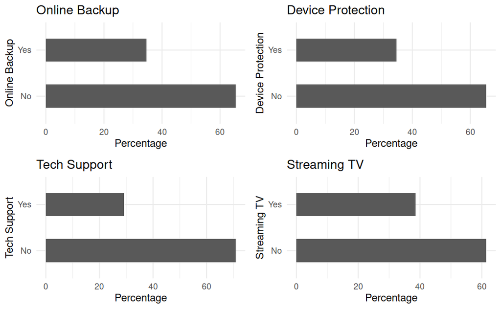

```r
p9 <- ggplot(Churn_Dataset, aes(x=OnlineBackup)) + ggtitle("Online Backup") + xlab("Online Backup") +
  geom_bar(aes(y = 100*(..count..)/sum(..count..)), width = 0.5) + ylab("Percentage") + coord_flip() + theme_minimal()
p10 <- ggplot(Churn_Dataset, aes(x=DeviceProtection)) + ggtitle("Device Protection") + xlab("Device Protection") +
  geom_bar(aes(y = 100*(..count..)/sum(..count..)), width = 0.5) + ylab("Percentage") + coord_flip() + theme_minimal()
p11 <- ggplot(Churn_Dataset, aes(x=TechSupport)) + ggtitle("Tech Support") + xlab("Tech Support") +
  geom_bar(aes(y = 100*(..count..)/sum(..count..)), width = 0.5) + ylab("Percentage") + coord_flip() + theme_minimal()
p12 <- ggplot(Churn_Dataset, aes(x=StreamingTV)) + ggtitle("Streaming TV") + xlab("Streaming TV") +
  geom_bar(aes(y = 100*(..count..)/sum(..count..)), width = 0.5) + ylab("Percentage") + coord_flip() + theme_minimal()
grid.arrange(p9, p10, p11, p12, ncol=2)
```

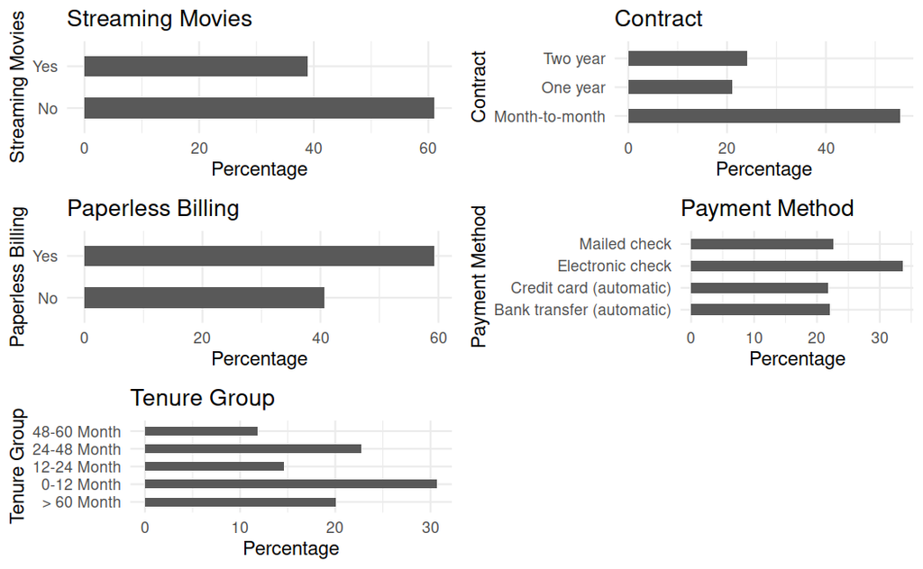

```r
p13 <- ggplot(Churn_Dataset, aes(x=StreamingMovies)) + ggtitle("Streaming Movies") + xlab("Streaming Movies") +
  geom_bar(aes(y = 100*(..count..)/sum(..count..)), width = 0.5) + ylab("Percentage") + coord_flip() + theme_minimal()
p14 <- ggplot(Churn_Dataset, aes(x=Contract)) + ggtitle("Contract") + xlab("Contract") +
  geom_bar(aes(y = 100*(..count..)/sum(..count..)), width = 0.5) + ylab("Percentage") + coord_flip() + theme_minimal()
p15 <- ggplot(Churn_Dataset, aes(x=PaperlessBilling)) + ggtitle("Paperless Billing") + xlab("Paperless Billing") +
  geom_bar(aes(y = 100*(..count..)/sum(..count..)), width = 0.5) + ylab("Percentage") + coord_flip() + theme_minimal()
p16 <- ggplot(Churn_Dataset, aes(x=PaymentMethod)) + ggtitle("Payment Method") + xlab("Payment Method") +
  geom_bar(aes(y = 100*(..count..)/sum(..count..)), width = 0.5) + ylab("Percentage") + coord_flip() + theme_minimal()
p17 <- ggplot(Churn_Dataset, aes(x=tenure_group)) + ggtitle("Tenure Group") + xlab("Tenure Group") +
  geom_bar(aes(y = 100*(..count..)/sum(..count..)), width = 0.5) + ylab("Percentage") + coord_flip() + theme_minimal()
grid.arrange(p13, p14, p15, p16, p17, ncol=2)
```

#——————————————————————————- # 3.Split the dataset into 80 training/20 test set and fit a decision tree to the training data. # Plot the tree, and interpret the results. (10 points) #——————————————————————————-

```r
intrain<- sample.int(n = nrow(Churn_Dataset), size = floor(.8*nrow(Churn_Dataset)), replace = F)

set.seed(2017)
training<- Churn_Dataset[intrain,]
testing<- Churn_Dataset[-intrain,]

training <- as.data.frame(lapply(training, unlist))
testing <- as.data.frame(lapply(testing, unlist))

drop <- c("Churn")
X_train = training[,!(names(training) %in% drop)]
y_train = training["Churn"]

X_test = testing[,!(names(testing) %in% drop)]
y_test = testing["Churn"]

X_test_for_ROC = X_test
y_test_for_ROC = y_test
```

#***************************************************************************************** #build the tree with all of the features

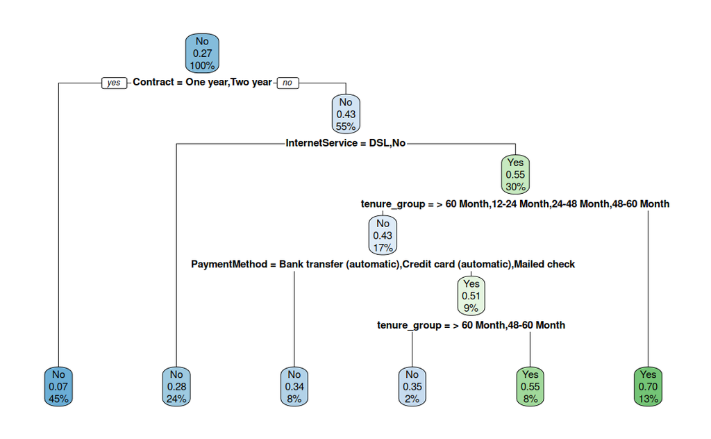

```r
library(party)
library(rpart)
library(rpart.plot)
DT <- rpart(Churn ~. , data = training, method = "class", control = rpart.control((cp = 0.05)))
# plot the tree
rpart.plot(DT,extra='auto')
```

#confusion matrix for Decision tree for the training data

```r
pred_tree_train_prediction <- predict(DT,X_train, type = "class")
CM_train = confusionMatrix(table(pred_tree_train_prediction,y_train$Churn))
print("Confusion Matrix for Decision Tree for training data");
```

```
[1] "Confusion Matrix for Decision Tree for training data"
```

```r
CM_train
```

```
Confusion Matrix and Statistics


pred_tree_train_prediction   No  Yes
                       No  3701  742
                       Yes  414  751

               Accuracy : 0.7939
                 95% CI : (0.783, 0.8044)
    No Information Rate : 0.7338
    P-Value [Acc > NIR] : < 2.2e-16

                  Kappa : 0.4327

 Mcnemar's Test P-Value : < 2.2e-16

            Sensitivity : 0.8994
            Specificity : 0.5030
         Pos Pred Value : 0.8330
         Neg Pred Value : 0.6446
             Prevalence : 0.7338
         Detection Rate : 0.6600
   Detection Prevalence : 0.7923
      Balanced Accuracy : 0.7012

       'Positive' Class : No
```

#confusion matrix for Decision tree for the testing data

```r
pred_tree_test_prediction <- predict(DT,X_test, type = "class")
CM_test = confusionMatrix(table(pred_tree_test_prediction,y_test$Churn))
print("Confusion Matrix for Decision Tree for testing data");
```

```
[1] "Confusion Matrix for Decision Tree for testing data"
```

```r
CM_test
```

```
Confusion Matrix and Statistics


pred_tree_test_prediction  No Yes
                      No  928 188
                      Yes 110 176

               Accuracy : 0.7874
                 95% CI : (0.7651, 0.8086)
    No Information Rate : 0.7404
    P-Value [Acc > NIR] : 2.343e-05

                  Kappa : 0.4058

 Mcnemar's Test P-Value : 8.177e-06

            Sensitivity : 0.8940
            Specificity : 0.4835
         Pos Pred Value : 0.8315
         Neg Pred Value : 0.6154
             Prevalence : 0.7404
         Detection Rate : 0.6619
   Detection Prevalence : 0.7960
      Balanced Accuracy : 0.6888

       'Positive' Class : No
```

#calculating the accuracy ot the model

```r
tab1 <- table(Predicted = pred_tree_train_prediction, Actual = y_train$Churn)
tab2 <- table(Predicted = pred_tree_test_prediction, Actual = y_test$Churn)
DT_Base_train_accuracy = sum(diag(tab1))/sum(tab1)
DT_Base_test_accuracy  = sum(diag(tab2))/sum(tab2)
print(paste('Decision Tree Training Accuracy with all feature :',DT_Base_train_accuracy))
```

```
[1] "Decision Tree Training Accuracy with all feature : 0.793865905848787"
```

```r
print(paste('Decision Tree Testing  Accuracy with all feature :',DT_Base_test_accuracy))
```

```
[1] "Decision Tree Testing  Accuracy with all feature : 0.787446504992867"
```

#================================================================================================ # 4. Try different ways to improve the decision tree algorithm (e.g., use different splitting strategies, prune # tree after splitting). Does pruning the tree improves the accuracy? # ———————————————————————————————

# use different splitting strartegy “information gain” and see the effect of using it on the model accuracy

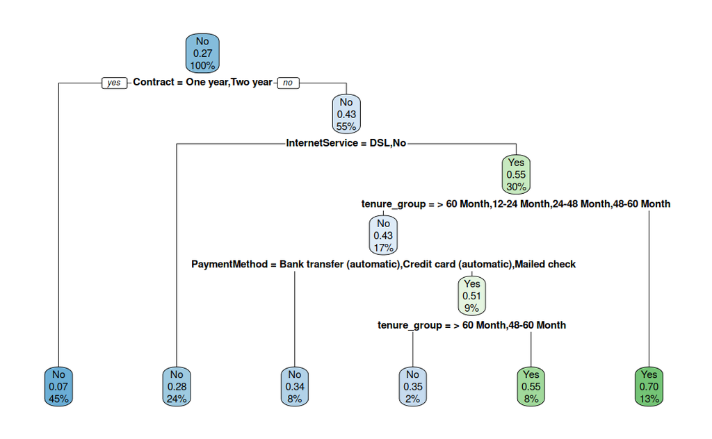

```r
# build the tree using information gain strategy
DT_information_gain <- rpart(training$Churn~ ., data = X_train, method = 'class',parms = list(split ="information"))
# plot the tree
rpart.plot(DT_information_gain,extra='auto')
```

#confusion matrix for Decision tree for the training data

```r
pred_tree_train_prediction_IG <- predict(DT_information_gain,X_train, type = "class")
CM_train_IG = confusionMatrix(table(pred_tree_train_prediction_IG,y_train$Churn))
print("Confusion Matrix for Decision Tree for training data");
```

```
[1] "Confusion Matrix for Decision Tree for training data"
```

```r
CM_train_IG
```

```
Confusion Matrix and Statistics


pred_tree_train_prediction_IG   No  Yes
                          No  3701  742
                          Yes  414  751

               Accuracy : 0.7939
                 95% CI : (0.783, 0.8044)
    No Information Rate : 0.7338
    P-Value [Acc > NIR] : < 2.2e-16

                  Kappa : 0.4327

 Mcnemar's Test P-Value : < 2.2e-16

            Sensitivity : 0.8994
            Specificity : 0.5030
         Pos Pred Value : 0.8330
         Neg Pred Value : 0.6446
             Prevalence : 0.7338
         Detection Rate : 0.6600
   Detection Prevalence : 0.7923
      Balanced Accuracy : 0.7012

       'Positive' Class : No
```

#confusion matrix for Decision tree for the testing data

```r
pred_tree_test_prediction_IG <- predict(DT_information_gain,X_test, type = "class")
CM_test_IG = confusionMatrix(table(pred_tree_test_prediction_IG,y_test$Churn))
print("Confusion Matrix for Decision Tree for training data");
```

```
[1] "Confusion Matrix for Decision Tree for training data"
```

```r
CM_test_IG
```

```
Confusion Matrix and Statistics


pred_tree_test_prediction_IG  No Yes
                         No  928 188
                         Yes 110 176

               Accuracy : 0.7874
                 95% CI : (0.7651, 0.8086)
    No Information Rate : 0.7404
    P-Value [Acc > NIR] : 2.343e-05

                  Kappa : 0.4058

 Mcnemar's Test P-Value : 8.177e-06

            Sensitivity : 0.8940
            Specificity : 0.4835
         Pos Pred Value : 0.8315
         Neg Pred Value : 0.6154
             Prevalence : 0.7404
         Detection Rate : 0.6619
   Detection Prevalence : 0.7960
      Balanced Accuracy : 0.6888

       'Positive' Class : No
```

#calculating the accuracy ot the model with information gain as a splitting strategy

```r
tab1_IG <- table(Predicted = pred_tree_train_prediction_IG, Actual = y_train$Churn)
tab2_IG <- table(Predicted = pred_tree_test_prediction_IG, Actual = y_test$Churn)

DT_IG_train_accuracy = sum(diag(tab1_IG))/sum(tab1_IG)
DT_IG_test_accuracy = sum(diag(tab2_IG))/sum(tab2_IG)

print(paste('Decision Tree Training Accuracy with information gain :',DT_IG_train_accuracy))
```

```
[1] "Decision Tree Training Accuracy with information gain : 0.793865905848787"
```

```r
print(paste('Decision Tree Testing  Accuracy with information gain :',DT_IG_test_accuracy))
```

```
[1] "Decision Tree Testing  Accuracy with information gain : 0.787446504992867"
```

```r
# Grow a tree with minsplit of 100 and max depth of 8

decision_tree_preprun = rpart(training$Churn~ ., data = X_train, method = "class",control = rpart.control(cp = 0.0001, maxdepth = 17,minsplit = 30))
# plot the tree
#rpart.plot(decision_tree_preprun,extra='auto')
# the prediction using the train data
y_pred_train_preprun_accuracy = predict(decision_tree_preprun, X_train, type = "class")
# the prediction using the test data
y_pred_test_preprun_accuracy = predict(decision_tree_preprun, X_test, type = "class")
# confucion matrix for the result of using training data
train_preprune_DT_CM=confusionMatrix(table(y_train$Churn,y_pred_train_preprun_accuracy))
# confucion matrix for the result of using testing data
test_preprune_DT_CM=confusionMatrix(table(y_test$Churn,y_pred_test_preprun_accuracy))
#calculating the accuracy
tab1_pre <- table(Predicted = y_pred_train_preprun_accuracy, Actual = y_train$Churn)
tab2_pre <- table(Predicted = y_pred_test_preprun_accuracy, Actual = y_test$Churn)
print("the confusion matix of Decsion tree with preprune strategy using the training data")
```

```
[1] "the confusion matix of Decsion tree with preprune strategy using the training data"
```

```r
print(train_preprune_DT_CM)
```

```
Confusion Matrix and Statistics

     y_pred_train_preprun_accuracy
        No  Yes
  No  3774  341
  Yes  613  880

               Accuracy : 0.8299
                 95% CI : (0.8198, 0.8396)
    No Information Rate : 0.7823
    P-Value [Acc > NIR] : < 2.2e-16

                  Kappa : 0.5378

 Mcnemar's Test P-Value : < 2.2e-16

            Sensitivity : 0.8603
            Specificity : 0.7207
         Pos Pred Value : 0.9171
         Neg Pred Value : 0.5894
             Prevalence : 0.7823
         Detection Rate : 0.6730
   Detection Prevalence : 0.7338
      Balanced Accuracy : 0.7905

       'Positive' Class : No
```

```r
print("the confusion matix of Decsion tree with preprune strategy using the testing  data")
```

```
[1] "the confusion matix of Decsion tree with preprune strategy using the testing  data"
```

```r
print(test_preprune_DT_CM)
```

```
Confusion Matrix and Statistics

     y_pred_test_preprun_accuracy
       No Yes
  No  908 130
  Yes 187 177

               Accuracy : 0.7739
                 95% CI : (0.7511, 0.7956)
    No Information Rate : 0.781
    P-Value [Acc > NIR] : 0.752172

                  Kappa : 0.3804

 Mcnemar's Test P-Value : 0.001659

            Sensitivity : 0.8292
            Specificity : 0.5765
         Pos Pred Value : 0.8748
         Neg Pred Value : 0.4863
             Prevalence : 0.7810
         Detection Rate : 0.6476
   Detection Prevalence : 0.7404
      Balanced Accuracy : 0.7029

       'Positive' Class : No
```

```r
DT_pre_train_accuracy = sum(diag(tab1))/sum(tab1)
DT_pre_test_accuracy = sum(diag(tab2))/sum(tab2)

print(paste('Decision Tree Training Accuracy by using preprune :',DT_pre_train_accuracy))
```

```
[1] "Decision Tree Training Accuracy by using preprune : 0.793865905848787"
```

```r
print(paste('Decision Tree Testing  Accuracy by using preprune :',DT_pre_test_accuracy))
```

```
[1] "Decision Tree Testing  Accuracy by using preprune : 0.787446504992867"
```

as the results shows the model overfitt because the training error is low but the testing error is high which means that the algorithm cann’t generalize correctly.

# Postprune the tree and see the effect on the accuracy

The idea here is to allow the decision tree to grow fully and observe the CP value. Next, we prune/cut the tree with the optimal CP value

```r
#Postpruning

# Prune the DT_base_model based on the optimal cp value
decision_tree_postpruned <- prune(DT, cp = 0.0084)
# plot the tree
#rpart.plot(decision_tree_preprun,extra='auto')
# the prediction using the train data
y_pred_train_postpruned_accuracy = predict(decision_tree_postpruned, X_train, type = "class")
# the prediction using the test data
y_pred_test_postpruned_accuracy = predict(decision_tree_postpruned, X_test, type = "class")
# confucion matrix for the result of using training data
train_postpruned_DT_CM=confusionMatrix(table(y_train$Churn,y_pred_train_postpruned_accuracy))
# confucion matrix for the result of using testing data
test_postpruned_DT_CM=confusionMatrix(table(y_test$Churn,y_pred_test_postpruned_accuracy))
#calculating the accuracy
tab1 <- table(Predicted = y_pred_train_postpruned_accuracy, Actual = y_train$Churn)
tab2 <- table(Predicted = y_pred_test_postpruned_accuracy, Actual = y_test$Churn)
print("the confusion matix of Decsion tree with postpruned strategy using the training data")
```

```
[1] "the confusion matix of Decsion tree with postpruned strategy using the training data"
```

```r
print(train_postpruned_DT_CM)
```

```
Confusion Matrix and Statistics

     y_pred_train_postpruned_accuracy
        No  Yes
  No  3701  414
  Yes  742  751

               Accuracy : 0.7939
                 95% CI : (0.783, 0.8044)
    No Information Rate : 0.7923
    P-Value [Acc > NIR] : 0.391

                  Kappa : 0.4327

 Mcnemar's Test P-Value : <2e-16

            Sensitivity : 0.8330
            Specificity : 0.6446
         Pos Pred Value : 0.8994
         Neg Pred Value : 0.5030
             Prevalence : 0.7923
         Detection Rate : 0.6600
   Detection Prevalence : 0.7338
      Balanced Accuracy : 0.7388

       'Positive' Class : No
```

```r
print("the confusion matix of Decsion tree with postpruned strategy using the testing  data")
```

```
[1] "the confusion matix of Decsion tree with postpruned strategy using the testing  data"
```

```r
print(test_postpruned_DT_CM)
```

```
Confusion Matrix and Statistics

     y_pred_test_postpruned_accuracy
       No Yes
  No  928 110
  Yes 188 176

               Accuracy : 0.7874
                 95% CI : (0.7651, 0.8086)
    No Information Rate : 0.796
    P-Value [Acc > NIR] : 0.7969

                  Kappa : 0.4058

 Mcnemar's Test P-Value : 8.177e-06

            Sensitivity : 0.8315
            Specificity : 0.6154
         Pos Pred Value : 0.8940
         Neg Pred Value : 0.4835
             Prevalence : 0.7960
         Detection Rate : 0.6619
   Detection Prevalence : 0.7404
      Balanced Accuracy : 0.7235

       'Positive' Class : No
```

```r
DT_post_train_accuracy=sum(diag(tab1))/sum(tab1)
DT_post_test_accuracy= sum(diag(tab2))/sum(tab2)

print(paste('Decision Tree Training Accuracy by using postpruned :',DT_post_train_accuracy))
```

```
[1] "Decision Tree Training Accuracy by using postpruned : 0.793865905848787"
```

```r
print(paste('Decision Tree Testing  Accuracy by using postpruned :',DT_post_test_accuracy))
```

```
[1] "Decision Tree Testing  Accuracy by using postpruned : 0.787446504992867"
```

```r
summary(Churn_Dataset)
```

```
    gender     SeniorCitizen Partner    Dependents PhoneService MultipleLines    InternetService OnlineSecurity OnlineBackup DeviceProtection
 Female:3475   No :5869      No :3617   No :4911   No : 680     No :4043      DSL        :2414   No :4995       No :4585     No :4592
 Male  :3535   Yes:1141      Yes:3393   Yes:2099   Yes:6330     Yes:2967      Fiber optic:3090   Yes:2015       Yes:2425     Yes:2418
                                                                              No         :1506



 TechSupport StreamingTV StreamingMovies           Contract    PaperlessBilling                   PaymentMethod  MonthlyCharges   Churn
 No :4970    No :4307    No :4279        Month-to-month:3853   No :2852         Bank transfer (automatic):1542   Min.   : 18.25   No :5153
 Yes:2040    Yes:2703    Yes:2731        One year      :1472   Yes:4158         Credit card (automatic)  :1521   1st Qu.: 35.75   Yes:1857
                                         Two year      :1685                    Electronic check         :2359   Median : 70.40
                                                                                Mailed check             :1588   Mean   : 64.89
                                                                                                                 3rd Qu.: 89.90
                                                                                                                 Max.   :118.75
      tenure_group
 > 60 Month :1407
 0-12 Month :2153
 12-24 Month:1024
 24-48 Month:1594
 48-60 Month: 832
```

#converting categorical variable to numeric values using LabelEncoder

```r
#install.packages("superml")
library(superml)
lbl = LabelEncoder$new()
Churn_Dataset$gender <-lbl$fit_transform(Churn_Dataset$gender)

lbl = LabelEncoder$new()
Churn_Dataset$SeniorCitizen <-lbl$fit_transform(Churn_Dataset$SeniorCitizen)

lbl = LabelEncoder$new()
Churn_Dataset$Partner <-lbl$fit_transform(Churn_Dataset$Partner)

lbl = LabelEncoder$new()
Churn_Dataset$Dependents <-lbl$fit_transform(Churn_Dataset$Dependents)

lbl = LabelEncoder$new()
Churn_Dataset$PhoneService <-lbl$fit_transform(Churn_Dataset$PhoneService)

lbl = LabelEncoder$new()
Churn_Dataset$MultipleLines<-lbl$fit_transform(Churn_Dataset$MultipleLines)

lbl = LabelEncoder$new()
Churn_Dataset$InternetService<-lbl$fit_transform(Churn_Dataset$InternetService)

lbl = LabelEncoder$new()
Churn_Dataset$OnlineSecurity<-lbl$fit_transform(Churn_Dataset$OnlineSecurity)

lbl = LabelEncoder$new()
Churn_Dataset$OnlineBackup<-lbl$fit_transform(Churn_Dataset$OnlineBackup)

lbl = LabelEncoder$new()
Churn_Dataset$DeviceProtection<-lbl$fit_transform(Churn_Dataset$DeviceProtection)

lbl = LabelEncoder$new()
Churn_Dataset$TechSupport<-lbl$fit_transform(Churn_Dataset$TechSupport)

lbl = LabelEncoder$new()
Churn_Dataset$StreamingTV<-lbl$fit_transform(Churn_Dataset$StreamingTV)

lbl = LabelEncoder$new()
Churn_Dataset$StreamingMovies<-lbl$fit_transform(Churn_Dataset$StreamingMovies)

lbl = LabelEncoder$new()
Churn_Dataset$Contract<-lbl$fit_transform(Churn_Dataset$Contract)

lbl = LabelEncoder$new()
Churn_Dataset$PaperlessBilling<-lbl$fit_transform(Churn_Dataset$PaperlessBilling)

lbl = LabelEncoder$new()
Churn_Dataset$PaymentMethod<-lbl$fit_transform(Churn_Dataset$PaymentMethod)

lbl = LabelEncoder$new()
Churn_Dataset$tenure_group<-lbl$fit_transform(Churn_Dataset$tenure_group)

lbl = LabelEncoder$new()
Churn_Dataset$Churn<-lbl$fit_transform(Churn_Dataset$Churn)
```

```r
str(Churn_Dataset)
```

```
'data.frame':   7010 obs. of  19 variables:
 $ gender          : num  0 1 1 1 0 0 1 0 0 1 ...
 $ SeniorCitizen   : num  0 0 0 0 0 0 0 0 0 0 ...
 $ Partner         : num  1 0 0 0 0 0 0 0 1 0 ...
 $ Dependents      : num  0 0 0 0 0 0 1 0 0 1 ...
 $ PhoneService    : num  0 1 1 0 1 1 1 0 1 1 ...
 $ MultipleLines   : num  0 0 0 0 0 1 1 0 1 0 ...
 $ InternetService : num  0 0 0 0 1 1 1 0 1 0 ...
 $ OnlineSecurity  : num  0 1 1 1 0 0 0 1 0 1 ...
 $ OnlineBackup    : num  1 0 1 0 0 0 1 0 0 1 ...
 $ DeviceProtection: num  0 1 0 1 0 1 0 0 1 0 ...
 $ TechSupport     : num  0 0 0 1 0 0 0 0 1 0 ...
 $ StreamingTV     : num  0 0 0 0 0 1 1 0 1 0 ...
 $ StreamingMovies : num  0 0 0 0 0 1 0 0 1 0 ...
 $ Contract        : num  0 1 0 1 0 0 0 0 0 1 ...
 $ PaperlessBilling: num  1 0 1 0 1 1 1 0 1 0 ...
 $ PaymentMethod   : num  2 3 3 0 2 2 1 3 2 0 ...
 $ MonthlyCharges  : num  29.9 57 53.9 42.3 70.7 ...
 $ Churn           : num  0 0 1 0 1 1 0 0 1 0 ...
 $ tenure_group    : num  1 3 1 3 1 1 2 1 3 0 ...
```

#split the dataset to training and testing

```r
intrain<- createDataPartition(Churn_Dataset$Churn,p=0.8,list=FALSE)
set.seed(2017)
training<- Churn_Dataset[intrain,]
testing<- Churn_Dataset[-intrain,]
```

```r
drop <- c("Churn")
X_train = training[,!(names(training) %in% drop)]
y_train = training["Churn"]

X_test = testing[,!(names(testing) %in% drop)]
y_test = testing["Churn"]
```

#================================================================================================== #implementation of XGBoost

```r
#install.packages('xgboost')
library(xgboost)
```

```r
#define final training and testing sets
xgb_train = xgb.DMatrix(data = as.matrix(X_train), label = y_train$Churn)
xgb_test = xgb.DMatrix(data = as.matrix(X_test), label = y_test$Churn)

#define watchlist
watchlist = list(train=xgb_train, test=xgb_test)

#fit XGBoost model and display training and testing data at each round
#the max.depth argument specifies how deep to grow the individual decision trees.
model = xgb.train(data = xgb_train, max.depth = 3, watchlist=watchlist, nrounds = 70)
```

```r
summary(model)
```

```
               Length Class              Mode
handle             1  xgb.Booster.handle externalptr
raw            85157  -none-             raw
niter              1  -none-             numeric
evaluation_log     3  data.table         list
call               5  -none-             call
params             2  -none-             list
callbacks          2  -none-             list
feature_names     18  -none-             character
nfeatures          1  -none-             numeric
```

#use xgBoost model to make predictions on test data

```r
pred_test = predict(model, xgb_test)
# print the first five predictions (in term of probability)
pred_test[1:5]
```

```
[1]  0.42194718  0.23720266  0.37072620  0.07039448 -0.03022996
```

#Convert prediction to factor type

```r
pred_y <- as.numeric(pred_test > 0.5)
pred_y
```

[output not shown]

#Create a confusion matrix for XGBoost model

```r
print("Confusion Matrix for xgBoost");
```

```
[1] "Confusion Matrix for xgBoost"
```

```r
tab4_xg <- confusionMatrix(table(Predicted = pred_y, Actual = y_test$Churn) )
tab4_xg
```

```
Confusion Matrix and Statistics

         Actual
Predicted   0   1
        0 941 186
        1  93 182

               Accuracy : 0.801
                 95% CI : (0.7791, 0.8216)
    No Information Rate : 0.7375
    P-Value [Acc > NIR] : 1.636e-08

                  Kappa : 0.4405

 Mcnemar's Test P-Value : 3.631e-08

            Sensitivity : 0.9101
            Specificity : 0.4946
         Pos Pred Value : 0.8350
         Neg Pred Value : 0.6618
             Prevalence : 0.7375
         Detection Rate : 0.6712
   Detection Prevalence : 0.8039
      Balanced Accuracy : 0.7023

       'Positive' Class : 0
```

```r
xg_test_acc = sum(diag(tab4_xg))/sum(tab4_xg)
```

[output not shown]

#===================================================================================

# 6.Train a deep neural network using Keras with 3 dense layers.

# Try changing the activation function or dropout rate. What effects does any of these have on the result?

#——————————————————————————-

```r
#install.packages("keras")
#install.packages("tensorflow")
#install.packages("mlbench")
#install.packages("neuralnet")
#library(tensorflow)
#install_tensorflow()
```

```r
library(keras)
library(mlbench)
library(dplyr)
library(magrittr)
library(neuralnet)
library(tensorflow)
```

# Building the Neural network model

```r
set.seed(42)
nn_model <- keras_model_sequential()
```

[output not shown]

```r
nn_model %>%
  layer_dense(units = 128, kernel_initializer = "uniform", activation = "relu",
              input_shape =ncol(subset(training, select= - c(Churn)))) %>%
  layer_dense( units = 64,kernel_initializer = "uniform",activation = "relu") %>%
  layer_dense(units = 1,kernel_initializer = "uniform",activation = "sigmoid")  %>%
  compile(optimizer = 'adam', loss = 'binary_crossentropy', metrics = c('accuracy') )

train_nn=fit(object = nn_model,
      x = as.matrix(subset(training, select= - c(Churn))),
      y =training$Churn,
      batch_size = 50, epochs =20,
      validation_split = 0.2 )
```

```r
# build the confusion matrix for the neural network
y_pred_nuralNetwork_model = nn_model %>% predict(as.matrix(subset(testing, select= - c(Churn)))) %>% `>` (0.5) %>% k_cast("int32") %>% as.vector()
test_nn=confusionMatrix(table(testing$Churn,y_pred_nuralNetwork_model))
test_nn
```

```
Confusion Matrix and Statistics

   y_pred_nuralNetwork_model
      0   1
  0 970  64
  1 208 160

               Accuracy : 0.806
                 95% CI : (0.7843, 0.8264)
    No Information Rate : 0.8402
    P-Value [Acc > NIR] : 0.9997

                  Kappa : 0.4267

 Mcnemar's Test P-Value : <2e-16

            Sensitivity : 0.8234
            Specificity : 0.7143
         Pos Pred Value : 0.9381
         Neg Pred Value : 0.4348
             Prevalence : 0.8402
         Detection Rate : 0.6919
   Detection Prevalence : 0.7375
      Balanced Accuracy : 0.7689

       'Positive' Class : 0
```

```r
tab5 <- table(Predicted = y_pred_nuralNetwork_model, Actual = y_test$Churn)
nn_test_acc = sum(diag(tab5))/sum(tab5)
print(paste('neural network Accuracy of testing data:',nn_test_acc))
```

```
[1] "neural network Accuracy of testing data: 0.803851640513552"
```

#=================================================================================== # Building the Neural network model after changing the activation function and see the effect on the results

```r
set.seed(42)
nn_model_Tanh <- keras_model_sequential()
nn_model_Tanh %>%
  layer_dense(units = 128, kernel_initializer = "uniform", activation = "tanh",
              input_shape =ncol(subset(training, select= - c(Churn)))) %>%
  layer_dense( units = 64,kernel_initializer = "uniform",activation = "tanh") %>%
  layer_dense(units = 1,kernel_initializer = "uniform",activation = "sigmoid")  %>%
  compile(optimizer = 'adam', loss = 'binary_crossentropy', metrics = c('accuracy') )

train_nn_Tanh=fit(object = nn_model_Tanh,
      x = as.matrix(subset(training, select= - c(Churn))),
      y =training$Churn,
      batch_size = 50, epochs =20,
      validation_split = 0.2 )
```

```r
# build the confusion matrix for the neural network
y_pred_nuralNetwork_model_Tanh = nn_model_Tanh %>% predict(as.matrix(subset(testing, select= - c(Churn)))) %>% `>` (0.5) %>% k_cast("int32") %>% as.vector()
test_nn_Tanh=confusionMatrix(table(testing$Churn,y_pred_nuralNetwork_model_Tanh))
test_nn_Tanh
```

```
Confusion Matrix and Statistics

   y_pred_nuralNetwork_model_Tanh
      0   1
  0 950  84
  1 199 169

               Accuracy : 0.7981
                 95% CI : (0.7762, 0.8189)
    No Information Rate : 0.8195
    P-Value [Acc > NIR] : 0.9819

                  Kappa : 0.4203

 Mcnemar's Test P-Value : 1.23e-11

            Sensitivity : 0.8268
            Specificity : 0.6680
         Pos Pred Value : 0.9188
         Neg Pred Value : 0.4592
             Prevalence : 0.8195
         Detection Rate : 0.6776
   Detection Prevalence : 0.7375
      Balanced Accuracy : 0.7474

       'Positive' Class : 0
```

```r
tab6 <- table(Predicted = y_pred_nuralNetwork_model_Tanh, Actual = y_test$Churn)
test_nn_Tanh_acc = sum(diag(tab6))/sum(tab6)
print(paste('neural network Accuracy of testing data using Tanh activation function :',test_nn_Tanh_acc))
```

```
[1] "neural network Accuracy of testing data using Tanh activation function : 0.798145506419401"
```

#===================================================================================================================== 7.Compare the performance of the models in terms of the following criteria: precision, recall, accuracy, F- measure. Identify the model that performed best and worst according to each criterion.

# collecting all the confusion matrices based on the testing data for all the models

```r
models_confusionMatrixs=list(CM_test,
                             CM_test_IG,
                             test_preprune_DT_CM,
                             test_postpruned_DT_CM,
                             tab4_xg,
                             test_nn,
                             test_nn_Tanh
                           )
models=list('Base Decision Tree','Decision Tree with info','Pre-pruning Decision Tree','Post-pruning Decision Tree','XGBoost','DNN model','DNN  with informationGain')
```

compare the performance of the models in term of the Precision # compare all the models

```r
idx=1
min_idx=1
max_idx=1
maxi_precision=-9999
mini_precision=99999
for (p in models_confusionMatrixs)
{
  prec = p$byClass['Pos Pred Value']
  print(models[idx])
  print(prec)
  print("==================================")
  idx=idx+1
}
```

[output not shown]

# find the best precsion model

```r
idx=1
min_idx=1 # by default the first element is the minimum
max_idx=1 # also by default the first element is the maximum
maxi_precision=-123456
mini_precision=123456
for (p in models_confusionMatrixs)
{
  # find the maximum value and updated the stored one
  if (p$byClass['Pos Pred Value'] > maxi_precision)
    {
    maxi_precision=p$byClass['Pos Pred Value']
    max_idx=idx
  }
  # find the maximum value and updated the stored one
  if (p$byClass['Pos Pred Value'] < mini_precision)
    {
    mini_precision=p$byClass['Pos Pred Value']
    min_idx=idx
  }
  #increase the index
  idx=idx+1
}
print("Best precision model")
```

```
[1] "Best precision model"
```

```r
print(models[max_idx])
```

```
[[1]]
[1] "Post-pruning Decision Tree"
```

```r
print(maxi_precision)
```

[output not shown]

```r
print("============================")
```

```
[1] "============================"
```

```r
print("Worest precision model")
```

```
[1] "Worest precision model"
```

```r
print(models[min_idx])
```

```
[[1]]
[1] "Base Decision Tree"
```

```r
print(mini_precision)
```

```
Pos Pred Value
     0.7897311
```

```r
print("============================")
```

```
[1] "============================"
```

compare the performance of the models in term of the recall

```r
idx=1
min_idx=1
max_idx=1
maxi_recall=-123456
mini_recall=123456
for (p in models_confusionMatrixs)
{
  recall_value = p$byClass['Sensitivity']
  print(models[idx])
  print(recall_value)
  print("==================================")
  idx=idx+1
}
```

[output not shown]

#find the Best and the worst recall

```r
idx=1
min_idx=1
max_idx=1
maxi_recall=-123456
mini_recall=123456
for (p in models_confusionMatrixs)
  {
  # find the maximun recall value and updated the stored one
  if (p$byClass['Sensitivity'] > maxi_recall)
    {
    maxi_recall=p$byClass['Sensitivity']
    max_idx=idx
  }
  # find the minimum value and update the stored one
  if (p$byClass['Sensitivity'] < mini_recall)
    {
    mini_recall=p$byClass['Sensitivity']
    min_idx=idx
  }
  #increase the counter
  idx=idx+1
}
print("Best recall model")
```

```
[1] "Best recall model"
```

```r
print(models[max_idx])
```

```
[[1]]
[1] "Base Decision Tree"
```

```r
print(maxi_recall)
```

```
Sensitivity
  0.9472141
```

```r
print("============================")
```

```
[1] "============================"
```

```r
print("Worest recall model")
```

```
[1] "Worest recall model"
```

```r
print(models[min_idx])
```

```
[[1]]
[1] "Post-pruning Decision Tree"
```

```r
print(mini_recall)
```

```
Sensitivity
  0.7897311
```

```r
print("============================")
```

```
[1] "============================"
```

compare all the model in term of accuracy

```r
idx=1
min_idx=1
max_idx=1
maxi_accuracy=-9999
mini_accuracy=99999
for (p in models_confusionMatrixs){
  accuracy=p$overall['Accuracy']
  print(models[idx])
  print(accuracy)
  print("==================================")
  idx=idx+1
}
```

[output not shown]

find the Best and the worst Accuracy

```r
idx=1
min_idx=1
max_idx=1
maxi_accuracy=-123456
mini_accuracy=123456
for (p in models_confusionMatrixs){
  #find the maximum accuracy and update the stored value
  if (p$overall['Accuracy'] > maxi_accuracy){
    maxi_accuracy=p$overall['Accuracy']
    max_idx=idx
  }
  # find the minimum accuracy and update the stores value
  if (p$overall['Accuracy'] < mini_accuracy){
    mini_accuracy=p$overall['Accuracy']
    min_idx=idx
  }
  idx=idx+1
}
print("Best accuracy model")
```

```
[1] "Best accuracy model"
```

```r
print(models[max_idx])
```

```
[[1]]
[1] "DNN model"
```

```r
print(maxi_accuracy)
```

```
 Accuracy
0.8038516
```

```r
print("===========================================")
```

```
[1] "==========================================="
```

```r
print("Worest accuracy model")
```

```
[1] "Worest accuracy model"
```

```r
print(models[min_idx])
```

```
[[1]]
[1] "Pre-pruning Decision Tree"
```

```r
print(mini_accuracy)
```

[output not shown]

```r
print("===========================================")
```

```
[1] "==========================================="
```

compare all the model in terms of F1-score

```r
idx=1
min_idx=1
max_idx=1
maxi_F1_score=-123456
mini_F1_score=123456
for (p in models_confusionMatrixs){
  f_score_value = f_measure = 2 * ((p$byClass['Pos Pred Value'] * p$byClass['Sensitivity']) / (p$byClass['Pos Pred Value'] + p$byClass['Sensitivity']))
  print(models[idx])
  print("f-score value")
  print(f_score_value)
  print("==================================")
  idx=idx+1
}
```

```
[[1]]
[1] "Base Decision Tree"

[1] "f-score value"
Pos Pred Value
     0.8613333
[1] "=================================="
[[1]]
[1] "Decision Tree with info"

[1] "f-score value"
Pos Pred Value
     0.8613333
[1] "=================================="
[[1]]
[1] "Pre-pruning Decision Tree"

[1] "f-score value"
Pos Pred Value
     0.8476011
[1] "=================================="
[[1]]
[1] "Post-pruning Decision Tree"

[1] "f-score value"
Pos Pred Value
     0.8613333
[1] "=================================="
[[1]]
[1] "XGBoost"

[1] "f-score value"
Pos Pred Value
     0.8708931
[1] "=================================="
[[1]]
[1] "DNN model"

[1] "f-score value"
Pos Pred Value
     0.8737953
[1] "=================================="
[[1]]
[1] "DNN  with informationGain"

[1] "f-score value"
Pos Pred Value
     0.8703619
[1] "=================================="
```

Best F1-score

```r
idx=1
min_idx=1
max_idx=1
maxi_F1_score=-123456
mini_F1_score=123123
for (p in models_confusionMatrixs)
  {
  # find the f-score value and update the stored values for both the minimum and the maximum values
  f_measure = 2 * ((p$byClass['Pos Pred Value'] * p$byClass['Sensitivity']) / (p$byClass['Pos Pred Value'] + p$byClass['Sensitivity']))
  if (f_measure > maxi_F1_score)
    {
    maxi_F1_score=f_measure
    max_idx=idx
    }
  if (f_measure < mini_F1_score)
    {
    mini_F1_score=f_measure
    min_idx=idx
   }
  idx=idx+1
}
print("Best F1_score model")
```

```
[1] "Best F1_score model"
```

```r
print(models[max_idx])
```

```
[[1]]
[1] "DNN model"
```

```r
print(maxi_F1_score)
```

```
Pos Pred Value
     0.8737953
```

```r
print("====================================")
```

```
[1] "===================================="
```

```r
print("Worest F1_score model")
```

```
[1] "Worest F1_score model"
```

```r
print(models[min_idx])
```

```
[[1]]
[1] "Pre-pruning Decision Tree"
```

```r
print(mini_F1_score)
```

```
Pos Pred Value
     0.8476011
```

```r
print("====================================")
```

```
[1] "===================================="
```

```r
# models
#DT
#DT_information_gain
#decision_tree_preprun
#decision_tree_postpruned
#model
#nn_model
#nn_model_Tanh

# DT Base
#CM_train
#CM_test
#DT_Base_train_accuracy
#DT_Base_test_accuracy
# DT IG
#CM_train_IG
#CM_test_IG
#DT_IG_train_accuracy
#DT_IG_test_accuracy
# DT prepruning
#train_preprune_DT_CM
#test_preprune_DT_CM
#DT_pre_train_accuracy
#DT_pre_test_accuracy
# DT Postpruning
#train_postpruned_DT_CM
#test_postpruned_DT_CM
#DT_post_train_accuracy
#DT_post_test_accuracy
# xgBoost
#tab4_xg # for testing data
#xg_test_acc
# NN Relu
#test_nn
#nn_test_acc
# NN Tanh
#test_nn_Tanh
#test_nn_Tanh_acc
```

#====================================================================================================================== 8.Use a ROC graph to compare the performance of the DT, XGboost & DNN techniques.

```r
library('pROC')
library(magrittr) # needs to be run every time you start R and want to use %>%
library(dplyr)    # alternatively, this also loads %>%
trained_models=
list(
  DT,
  DT_information_gain,
  decision_tree_preprun,
  decision_tree_postpruned,
  model,
  nn_model,
  nn_model_Tanh
)
```

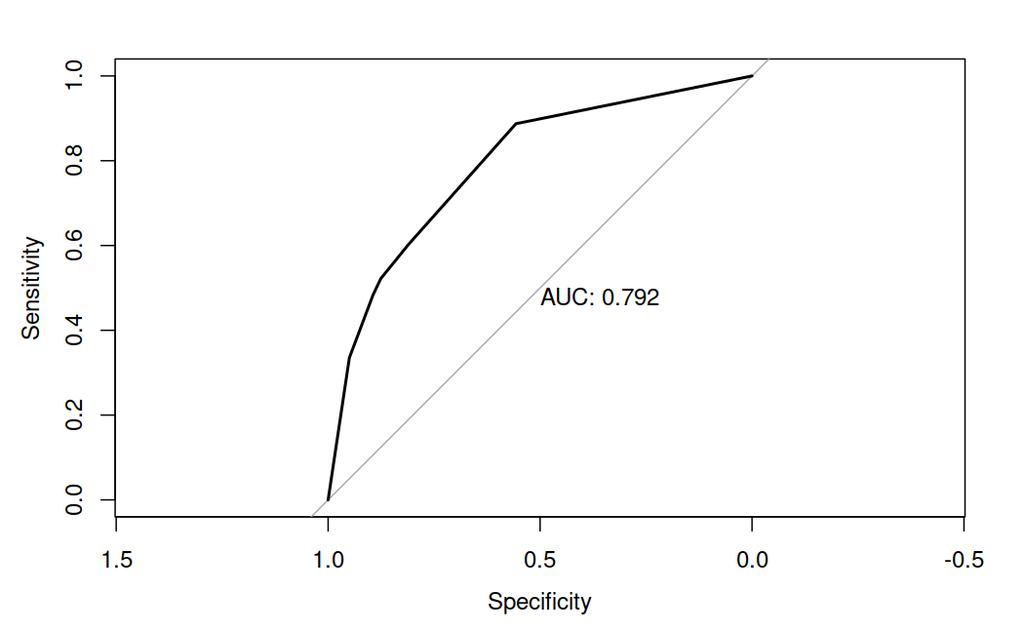

```r
library(pROC)
#DT
testrf_prob = predict(DT, X_test_for_ROC,type = "prob")
roc <- roc(y_test_for_ROC$Churn, testrf_prob[,2], plot = TRUE, print.auc = TRUE)
```

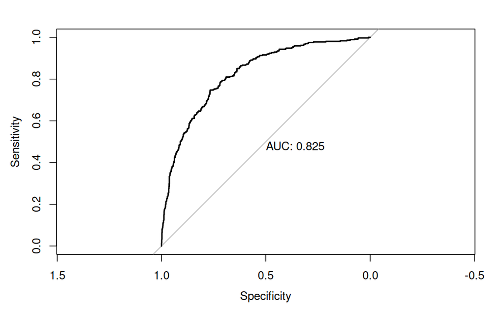

```r
#XGboost
testrf_prob = predict(model, xgb_test)
roc <- roc(y_test$Churn, testrf_prob, plot = TRUE, print.auc = TRUE)
```

```
Warning in roc.default(y_test$Churn, testrf_prob, plot = TRUE, print.auc = TRUE) :
  Deprecated use a matrix as predictor. Unexpected results may be produced, please pass a numeric vector.
```

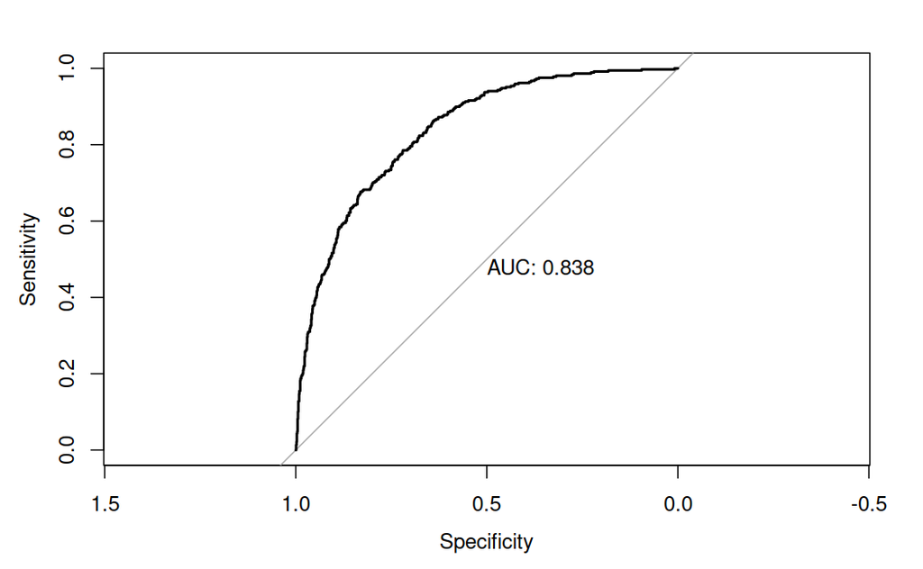

```r
#DNN technique
testrf_prob = nn_model %>% predict(as.matrix(subset(testing, select= - c(Churn))))
roc <- roc(y_test$Churn, testrf_prob, plot = TRUE, print.auc = TRUE)
```

#===================================================================================================================== Note that Part B in a seperated file, because some libraries works in a different version for R #References for part A: https://towardsdatascience.com/hands-on-churn-prediction-with-r-and-comparison-of-different-models-for-churn-prediction-4b79011a082a https://www.researchgate.net/publication/338735689_Bayes_Risk_Post-Pruning_in_Decision_Tree_to_Overcome_Overfitting_Problem_on_Customer_Churn_Classification https://dzone.com/articles/decision-trees-and-pruning-in-r https://www.statology.org/xgboost-in-r/